# Zad1 PostgreSQL / Elasticsearch

Artur Koliński

# Dane

Na potrzeby tego zadania skorzystałem z danych Postcodes from UK które można pobrać tutaj http://ovh.to/73NLuDk, plik postcodes.csv rozmiar 275mb, ilość rekordów 2 532 817.

## Struktura danych

```
CREATE TABLE postcodes (
  postcode VARCHAR,
  status VARCHAR,
  usertype VARCHAR,
  easting FLOAT,
  northing FLOAT,
  positional_quality_indicator FLOAT,
  country VARCHAR,
  latitude FLOAT,
  longitude FLOAT,
  postcode_no_space VARCHAR,
  postcode_fixed_width_seven VARCHAR,
  postcode_fixed_width_eight VARCHAR,
  postcode_area VARCHAR,
  postcode_district VARCHAR,
  postcode_sector VARCHAR,
  outcode VARCHAR,
  incode VARCHAR
);
```

## Przykładowy rekord

```
AB1 0AA,terminated,small,385386,801193,1,Scotland,57.101474,-2.242851,AB10AA,AB1 0AA,AB1  0AA,AB,AB1,AB1 0,AB1,0AA
```

## PostgreSQL 9.6

Wszystkie polecenia znajdują się w pliku https://github.com/artkolinski/NoSQL/blob/master/scripts/postgresAll.sql Uruchamiamy bazę danych, tworzymy tabelę skryptem https://github.com/artkolinski/NoSQL/blob/master/scripts/create.sql oraz włączamy pomiar czasu.

```
\i create.sql;
\timing;
```

Kopiujemy dane z pliku CSV do bazy

```
COPY postcodes FROM ' C:\postcodes.csv ' DELIMITER ',' CSV;

COPY 2532817

Czas: 11002,358 ms
```

Sprawdzamy ile jest rekordów

```
SELECT COUNT(*) FROM postcodes;

  count
---------
 2532817
(1 wiersz)

Czas: 370,137 ms
```

Wybieramy kurs wschodni oraz północny dla kodu ‘WR3 8AS’

```
select easting, northing from postcodes where postcode = 'WR3 8AS';

 easting | northing
---------+----------
  384785 |   256819
(1 wiersz)

Czas: 296,812 ms
```

Szukamy dystryktu kodu pocztowego ‘M1 1AA’:

```
select postcode_district from postcodes where postcode_fixed_width_eight = 'M1   1AA';

postcode_district
-------------------
 M1
(1 wiersz)

Czas: 408,702 ms
```

Szukamy współrzędnych geograficznych dla kodu ‘RG46SU’:

```
select latitude, longitude from postcodes where postcode_no_space = 'RG46SU';

 latitude  | longitude
-----------+-----------
 51.470889 | -0.918018
(1 wiersz)

Czas: 383,943 ms
```

Teraz chcemy znaleźć kurs wschodni oraz północny wieży w Londynie “The Tower of London” w celu dalszej bardziej ciekawej obróbki:

```
select easting, northing from postcodes where postcode = 'EC3N 4AB';

 easting | northing
---------+----------
  533602 |   180570
(1 wiersz)

Czas: 285,792 ms
```

Szukamy 10 najbliższych kodów pocztowych dla “The Tower of London” oraz obliczamy ich odległość:

```
select postcode, sqrt(pow(abs(533668 - easting),2) + pow(abs(180551 - northing),2)) as distance from postcodes order by distance limit 10;

 postcode |     distance
----------+------------------
 EC3N 4AE | 68.6804193347711
 EC3N 4AB | 68.6804193347711
 EC3N 4AQ | 85.7962703152066
 EC3N 4AD | 99.9849988748312
 E1W 1AY  | 111.162043881893
 E1W 1XA  | 111.162043881893
 E1W 1XE  | 111.162043881893
 E1W 1UU  | 111.162043881893
 E1W 1UY  | 111.162043881893
 E1W 1UN  | 111.162043881893
(10 wierszy)

Czas: 1311,928 ms
```

Zmieniamy trochę polecenie aby uzyskać tylko aktywne kody w obszarze 1km x 1km od “The Tower of London” ale bez kodu “The Tower of London” którym jest ‘EC3N 4AB’:

```
select postcode, sqrt(pow(abs(533668 - easting),2) + pow(abs(180551 - northing),2)) as distance from postcodes where status = 'live' and easting between 533668 - 500 and 533668 + 500 and northing between 180551 - 500 and 180551 + 500 and postcode != 'EC3N 4AB' order by distance limit 10;

postcode |     distance
----------+------------------
 EC3N 4AE | 68.6804193347711
 E1W 1YL  | 111.162043881893
 E1W 1AY  | 111.162043881893
 E1W 1XB  | 111.162043881893
 E1W 1UN  | 111.162043881893
 E1W 1LE  | 125.251746494809
 E1W 1DD  | 135.594985158006
 E1W 1BA  | 145.248063670398
 EC3N 4DR | 196.468827043885
 E1W 1LD  |  220.67623342807
(10 wierszy)

Czas: 342,497 ms
```

Zrobienie wykresu dla ostatniego polecenia:

[output not shown]

Użycie RStudio do rysowania

```
dane <- read.csv('chart.csv', sep=',')
plot(dane$postcode, dane$distance, cex = 0.5, main="Postcode / Distance", xlab = "Postcode ", ylab = "Distance", las = 1)
```

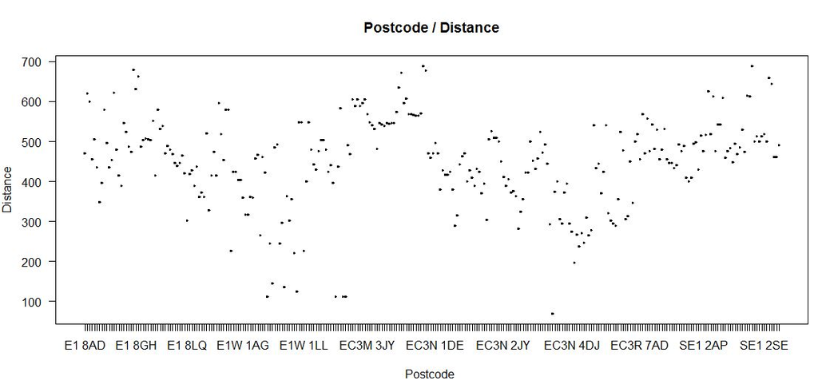

## ElasticSearch 5.2.2

Do importu danych z csv użyłem programu logstash-5.3.0, mój skrypt importujący wygląda następująco:

```
input {
stdin {
type => "stdin-type"
}
file {
path => ["C:/postcodes.csv"]
start_position => "beginning"
}
}
filter {
csv {
columns => ["postcode","status","usertype","easting","northing","positional_quality_indicator","country","latitude","longitude","postcode_no_space","postcode_fixed_width_seven","postcode_fixed_width_eight","postcode_area","postcode_district","postcode_sector","outcode","incode"]
separator => ","
}
}
output {
stdout { codec => rubydebug }
elasticsearch {
hosts => "localhost:9200"
index => "csv_index"
}
}
Czas importu ~32min
```

Sprawdzenie liczby zaimportowanych danych

```
curl -XGET localhost:9200/csv_index/_count
{"count":2532817,"_shards":{"total":5,"successful":5,"failed":0}}
```

Sprawdzmy czy maping został dokonany prawidłowo podczas importu

[output not shown]

Szukamy kodu ‘M11AA’:

```
curl -s "http://localhost:9200/csv_index/_search?pretty=true&q=postcode_no_space:'M11AA'"
{
  "took" : 21,
  "timed_out" : false,
  "_shards" : {
    "total" : 5,
    "successful" : 5,
    "failed" : 0
  },
  "hits" : {
    "total" : 1,
    "max_score" : 12.727802,
    "hits" : [
      {
        "_index" : "csv_index",
        "_type" : "logs",
        "_id" : "AVsz8J-1mvZBZk3K4IVs",
        "_score" : 12.727802,
        "_source" : {
          "postcode_district" : "M1",
          "country" : "England",
          "easting" : "385022",
          "positional_quality_indicator" : "1",
          "latitude" : "53.487362",
          "postcode_fixed_width_eight" : "M1   1AA",
          "postcode" : "M1 1AA",
          "usertype" : "large",
          "message" : "M1 1AA,terminated,large,385022,398985,1,England,53.487362,-2.227197,M11AA,M1  1AA,M1   1AA,M,M1,M1 1,M1,1AA",
          "northing" : "398985",
          "path" : "C:/postcodes.csv",
          "postcode_sector" : "M1 1",
          "@timestamp" : "2017-04-03T13:10:59.054Z",
          "postcode_fixed_width_seven" : "M1  1AA",
          "outcode" : "M1",
          "@version" : "1",
          "host" : "DESKTOP-MJ9FGTH",
          "postcode_area" : "M",
          "postcode_no_space" : "M11AA",
          "incode" : "1AA",
          "status" : "terminated",
          "longitude" : "-2.227197"
        }
      }
    ]
  }
}
```

Szukamy kodu ‘RG46SU’:

```
curl -s "http://localhost:9200/csv_index/_search?pretty=true&q=postcode_no_space:'RG46SU'"
{
  "took" : 2,
  "timed_out" : false,
  "_shards" : {
    "total" : 5,
    "successful" : 5,
    "failed" : 0
  },
  "hits" : {
    "total" : 1,
    "max_score" : 12.728338,
    "hits" : [
      {
        "_index" : "csv_index",
        "_type" : "logs",
        "_id" : "AVsz9K54mvZBZk3K6NHf",
        "_score" : 12.728338,
        "_source" : {
          "postcode_district" : "RG4",
          "country" : "England",
          "easting" : "475249",
          "positional_quality_indicator" : "1",
          "latitude" : "51.470889",
          "postcode_fixed_width_eight" : "RG4  6SU",
          "postcode" : "RG4 6SU",
          "usertype" : "large",
          "message" : "RG4 6SU,live,large,475249,175213,1,England,51.470889,-0.918018,RG46SU,RG4 6SU,RG4  6SU,RG,RG4,RG4 6,RG4,6SU",
          "northing" : "175213",
          "path" : "C:/postcodes.csv",
          "postcode_sector" : "RG4 6",
          "@timestamp" : "2017-04-03T13:15:24.975Z",
          "postcode_fixed_width_seven" : "RG4 6SU",
          "outcode" : "RG4",
          "@version" : "1",
          "host" : "DESKTOP-MJ9FGTH",
          "postcode_area" : "RG",
          "postcode_no_space" : "RG46SU",
          "incode" : "6SU",
          "status" : "live",
          "longitude" : "-0.918018"
        }
      }
    ]
  }
}
```

Szukamy współrzędnych geograficznych dla kodu ‘RG46SU’:

```
Curl -s "http://localhost:9200/csv_index/_search?pretty=true&q=postcode_no_space:'RG46SU'&filter_path=took,hits.hits._source.longitude,hits.hits._source.latitude"
{
  "took" : 2,
  "hits" : {
    "hits" : [
      {
        "_source" : {
          "latitude" : "51.470889",
          "longitude" : "-0.918018"
        }
      }
    ]
  }
}
```

Teraz chcemy znaleźć współrzędne wieży w Londynie “The Tower of London”:

[output not shown]

Następnie chcemy znaleźć kurs wschodni oraz północny wieży w Londynie “The Tower of London”:

```
Curl -s "http://localhost:9200/csv_index/_search?pretty=true&q=postcode_no_space:'EC3N4AB'&filter_path=took,hits.hits._source.easting,hits.hits._source.northing"
{
  "took" : 2,
  "hits" : {
    "hits" : [
      {
        "_source" : {
          "easting" : "533602",
          "northing" : "180570"
        }
      }
    ]
  }
}
```

## Podsumowanie

[output not shown]

Skala ocen 1-10 (więcej = lepiej)

| Kryteria | ElasticSearch | PostgreSQL |
| --- | --- | --- |
| import danych | 2 | 10 |
| latwość użycia | 5 | 7 |
| predkość nauki | 1 | 8 |
| czas odpowiedzi | 10 | 1 |
| czas tworzenia zap. | 1 | 9 |